# Phân tích Default of Credit Card Clients

Classification

Trần Minh Châu

2026-04-16

# 0. Thư viện

```r
library(dplyr)
library(corrplot)
library(skimr)       # thống kê mô tả nhanh
library(tidyverse)
library(readxl)
library(MASS)      # lda(), qda()
library(class)     # knn()
library(pROC)      # roc(), auc()
library(patchwork)
library(scales)
library(broom)     # tidy() cho glm
```

# PHẦN 1 – KHÁM PHÁ DỮ LIỆU (EDA)

# 1. Đọc & Làm sạch dữ liệu

```r
# Dòng đầu là tên cột viết tắt (X1, X2...), dòng 2 mới là tên thật
# Dùng skip = 1 để bỏ dòng đầu
df_raw <- read_xls(
  "default of credit card clients.xls",
  skip = 1          # bỏ hàng header phụ (X1, X2, ...)
)

# Đổi tên cột target cho dễ dùng
df <- df_raw %>%
  rename(DEFAULT = `default payment next month`)

# Xem cấu trúc
glimpse(df)
```

```
## Rows: 30,000
## Columns: 25
## $ ID        <dbl> 1, 2, 3, 4, 5, 6, 7, 8, 9, 10, 11, 12, 13, 14, 15, 16, 17, 1…
## $ LIMIT_BAL <dbl> 20000, 120000, 90000, 50000, 50000, 50000, 500000, 100000, 1…
## $ SEX       <dbl> 2, 2, 2, 2, 1, 1, 1, 2, 2, 1, 2, 2, 2, 1, 1, 2, 1, 1, 2, 2, …
## $ EDUCATION <dbl> 2, 2, 2, 2, 2, 1, 1, 2, 3, 3, 3, 1, 2, 2, 1, 3, 1, 1, 1, 1, …
## $ MARRIAGE  <dbl> 1, 2, 2, 1, 1, 2, 2, 2, 1, 2, 2, 2, 2, 2, 2, 3, 2, 1, 1, 2, …
## $ AGE       <dbl> 24, 26, 34, 37, 57, 37, 29, 23, 28, 35, 34, 51, 41, 30, 29, …
## $ PAY_0     <dbl> 2, -1, 0, 0, -1, 0, 0, 0, 0, -2, 0, -1, -1, 1, 0, 1, 0, 0, 1…
## $ PAY_2     <dbl> 2, 2, 0, 0, 0, 0, 0, -1, 0, -2, 0, -1, 0, 2, 0, 2, 0, 0, -2,…
## $ PAY_3     <dbl> -1, 0, 0, 0, -1, 0, 0, -1, 2, -2, 2, -1, -1, 2, 0, 0, 2, 0, …
## $ PAY_4     <dbl> -1, 0, 0, 0, 0, 0, 0, 0, 0, -2, 0, -1, -1, 0, 0, 0, 2, -1, -…
## $ PAY_5     <dbl> -2, 0, 0, 0, 0, 0, 0, 0, 0, -1, 0, -1, -1, 0, 0, 0, 2, -1, -…
## $ PAY_6     <dbl> -2, 2, 0, 0, 0, 0, 0, -1, 0, -1, -1, 2, -1, 2, 0, 0, 2, -1, …
## $ BILL_AMT1 <dbl> 3913, 2682, 29239, 46990, 8617, 64400, 367965, 11876, 11285,…
## $ BILL_AMT2 <dbl> 3102, 1725, 14027, 48233, 5670, 57069, 412023, 380, 14096, 0…
## $ BILL_AMT3 <dbl> 689, 2682, 13559, 49291, 35835, 57608, 445007, 601, 12108, 0…
## $ BILL_AMT4 <dbl> 0, 3272, 14331, 28314, 20940, 19394, 542653, 221, 12211, 0, …
## $ BILL_AMT5 <dbl> 0, 3455, 14948, 28959, 19146, 19619, 483003, -159, 11793, 13…
## $ BILL_AMT6 <dbl> 0, 3261, 15549, 29547, 19131, 20024, 473944, 567, 3719, 1391…
## $ PAY_AMT1  <dbl> 0, 0, 1518, 2000, 2000, 2500, 55000, 380, 3329, 0, 2306, 218…
## $ PAY_AMT2  <dbl> 689, 1000, 1500, 2019, 36681, 1815, 40000, 601, 0, 0, 12, 99…
## $ PAY_AMT3  <dbl> 0, 1000, 1000, 1200, 10000, 657, 38000, 0, 432, 0, 50, 8583,…
## $ PAY_AMT4  <dbl> 0, 1000, 1000, 1100, 9000, 1000, 20239, 581, 1000, 13007, 30…
## $ PAY_AMT5  <dbl> 0, 0, 1000, 1069, 689, 1000, 13750, 1687, 1000, 1122, 3738, …
## $ PAY_AMT6  <dbl> 0, 2000, 5000, 1000, 679, 800, 13770, 1542, 1000, 0, 66, 364…
## $ DEFAULT   <dbl> 1, 1, 0, 0, 0, 0, 0, 0, 0, 0, 0, 0, 0, 1, 0, 0, 1, 0, 0, 0, …
```

```r
cat("Số hàng:", nrow(df), "\n")
```

```
## Số hàng: 30000
```

```r
cat("Số cột :", ncol(df), "\n")
```

```
## Số cột : 25
```

```r
cat("\nKiểu dữ liệu từng cột:\n")
```

```
##
## Kiểu dữ liệu từng cột:
```

```r
sapply(df, class)
```

```
##        ID LIMIT_BAL       SEX EDUCATION  MARRIAGE       AGE     PAY_0     PAY_2
## "numeric" "numeric" "numeric" "numeric" "numeric" "numeric" "numeric" "numeric"
##     PAY_3     PAY_4     PAY_5     PAY_6 BILL_AMT1 BILL_AMT2 BILL_AMT3 BILL_AMT4
## "numeric" "numeric" "numeric" "numeric" "numeric" "numeric" "numeric" "numeric"
## BILL_AMT5 BILL_AMT6  PAY_AMT1  PAY_AMT2  PAY_AMT3  PAY_AMT4  PAY_AMT5  PAY_AMT6
## "numeric" "numeric" "numeric" "numeric" "numeric" "numeric" "numeric" "numeric"
##   DEFAULT
## "numeric"
```

## 1.1 Kiểm tra Missing Values

```r
missing_summary <- df %>%
  summarise(across(everything(), ~sum(is.na(.)))) %>%
  pivot_longer(everything(), names_to = "column", values_to = "missing_count") %>%
  mutate(missing_pct = missing_count / nrow(df) * 100)

missing_summary
```

| column | missing_count | missing_pct |
| --- | --- | --- |
| ID | 0 | 0 |
| LIMIT_BAL | 0 | 0 |
| SEX | 0 | 0 |
| EDUCATION | 0 | 0 |
| MARRIAGE | 0 | 0 |
| AGE | 0 | 0 |
| PAY_0 | 0 | 0 |
| PAY_2 | 0 | 0 |
| PAY_3 | 0 | 0 |
| PAY_4 | 0 | 0 |

[output cut: 15 more lines]

> ✔ Không có missing value – dataset hoàn chỉnh 30,000 quan sát.

## 1.2 Thống kê mô tả

```r
skim(df)
```

Data summary

| Name | df |
| --- | --- |
| Number of rows | 30000 |
| Number of columns | 25 |
| _______________________ |  |
| Column type frequency: |  |
| numeric | 25 |
| ________________________ |  |
| Group variables | None |

**Variable type: numeric**

| skim_variable | n_missing | complete_rate | mean | sd | p0 | p25 | p50 | p75 | p100 | hist |
| --- | --- | --- | --- | --- | --- | --- | --- | --- | --- | --- |
| ID | 0 | 1 | 15000.50 | 8660.40 | 1 | 7500.75 | 15000.5 | 22500.25 | 30000 | ▇▇▇▇▇ |
| LIMIT_BAL | 0 | 1 | 167484.32 | 129747.66 | 10000 | 50000.00 | 140000.0 | 240000.00 | 1000000 | ▇▃▁▁▁ |
| SEX | 0 | 1 | 1.60 | 0.49 | 1 | 1.00 | 2.0 | 2.00 | 2 | ▅▁▁▁▇ |
| EDUCATION | 0 | 1 | 1.85 | 0.79 | 0 | 1.00 | 2.0 | 2.00 | 6 | ▆▇▃▁▁ |
| MARRIAGE | 0 | 1 | 1.55 | 0.52 | 0 | 1.00 | 2.0 | 2.00 | 3 | ▁▇▁▇▁ |
| AGE | 0 | 1 | 35.49 | 9.22 | 21 | 28.00 | 34.0 | 41.00 | 79 | ▇▇▂▁▁ |
| PAY_0 | 0 | 1 | -0.02 | 1.12 | -2 | -1.00 | 0.0 | 0.00 | 8 | ▇▂▁▁▁ |
| PAY_2 | 0 | 1 | -0.13 | 1.20 | -2 | -1.00 | 0.0 | 0.00 | 8 | ▇▁▁▁▁ |
| PAY_3 | 0 | 1 | -0.17 | 1.20 | -2 | -1.00 | 0.0 | 0.00 | 8 | ▇▁▁▁▁ |
| PAY_4 | 0 | 1 | -0.22 | 1.17 | -2 | -1.00 | 0.0 | 0.00 | 8 | ▇▁▁▁▁ |
| PAY_5 | 0 | 1 | -0.27 | 1.13 | -2 | -1.00 | 0.0 | 0.00 | 8 | ▇▁▁▁▁ |
| PAY_6 | 0 | 1 | -0.29 | 1.15 | -2 | -1.00 | 0.0 | 0.00 | 8 | ▇▁▁▁▁ |
| BILL_AMT1 | 0 | 1 | 51223.33 | 73635.86 | -165580 | 3558.75 | 22381.5 | 67091.00 | 964511 | ▇▃▁▁▁ |
| BILL_AMT2 | 0 | 1 | 49179.08 | 71173.77 | -69777 | 2984.75 | 21200.0 | 64006.25 | 983931 | ▇▁▁▁▁ |
| BILL_AMT3 | 0 | 1 | 47013.15 | 69349.39 | -157264 | 2666.25 | 20088.5 | 60164.75 | 1664089 | ▇▁▁▁▁ |
| BILL_AMT4 | 0 | 1 | 43262.95 | 64332.86 | -170000 | 2326.75 | 19052.0 | 54506.00 | 891586 | ▇▃▁▁▁ |
| BILL_AMT5 | 0 | 1 | 40311.40 | 60797.16 | -81334 | 1763.00 | 18104.5 | 50190.50 | 927171 | ▇▁▁▁▁ |
| BILL_AMT6 | 0 | 1 | 38871.76 | 59554.11 | -339603 | 1256.00 | 17071.0 | 49198.25 | 961664 | ▁▇▁▁▁ |
| PAY_AMT1 | 0 | 1 | 5663.58 | 16563.28 | 0 | 1000.00 | 2100.0 | 5006.00 | 873552 | ▇▁▁▁▁ |
| PAY_AMT2 | 0 | 1 | 5921.16 | 23040.87 | 0 | 833.00 | 2009.0 | 5000.00 | 1684259 | ▇▁▁▁▁ |
| PAY_AMT3 | 0 | 1 | 5225.68 | 17606.96 | 0 | 390.00 | 1800.0 | 4505.00 | 896040 | ▇▁▁▁▁ |
| PAY_AMT4 | 0 | 1 | 4826.08 | 15666.16 | 0 | 296.00 | 1500.0 | 4013.25 | 621000 | ▇▁▁▁▁ |
| PAY_AMT5 | 0 | 1 | 4799.39 | 15278.31 | 0 | 252.50 | 1500.0 | 4031.50 | 426529 | ▇▁▁▁▁ |
| PAY_AMT6 | 0 | 1 | 5215.50 | 17777.47 | 0 | 117.75 | 1500.0 | 4000.00 | 528666 | ▇▁▁▁▁ |
| DEFAULT | 0 | 1 | 0.22 | 0.42 | 0 | 0.00 | 0.0 | 0.00 | 1 | ▇▁▁▁▂ |

> ⚠️ Từ thống kê mô tả cho thấy biến EDUCATION và MARRIAGE xuất hiện một số giá trị không hợp lệ (như EDUCATION có các giá trị 0, 5, 6 và MARRIAGE có giá trị 0), không thuộc các nhóm phân loại đã định nghĩa. Do đó, cần thực hiện bước làm sạch dữ liệu bằng cách gộp các giá trị bất thường vào nhóm “Others”.

## 1.3 Làm sạch dữ liệu

```r
df <- df_raw %>%
  rename(DEFAULT = `default payment next month`) %>%
  mutate(
    EDUCATION = as.numeric(as.character(EDUCATION)),
    MARRIAGE  = as.numeric(as.character(MARRIAGE)),
    SEX       = as.numeric(as.character(SEX)),

    EDUCATION = case_when(
      is.na(EDUCATION) ~ 4,
      EDUCATION %in% c(1,2,3) ~ EDUCATION,
      TRUE ~ 4
    ),

    MARRIAGE = case_when(
      is.na(MARRIAGE) ~ 3,
      MARRIAGE %in% c(1,2,3) ~ MARRIAGE,
      TRUE ~ 3          # gộp giá trị bất hợp lệ (0, ...) vào nhóm "Others"
    ),

    SEX = case_when(
      SEX %in% c(1,2) ~ SEX,
      TRUE ~ NA_real_
    ),

    EDUCATION = factor(EDUCATION,
                       levels = c(1,2,3,4),
                       labels = c("Graduate", "University", "High School", "Others")),

    MARRIAGE = factor(MARRIAGE,
                      levels = c(1,2,3),
                      labels = c("Married", "Single", "Others")),

    SEX = factor(SEX,
                 levels = c(1,2),
                 labels = c("Male", "Female"))
  )
```

```r
table(df$EDUCATION)
```

```
##
##    Graduate  University High School      Others
##       10585       14030        4917         468
```

```r
table(df$MARRIAGE)
```

```
##
## Married  Single  Others
##   13659   15964     377
```

# 2. Biến Target (DEFAULT)

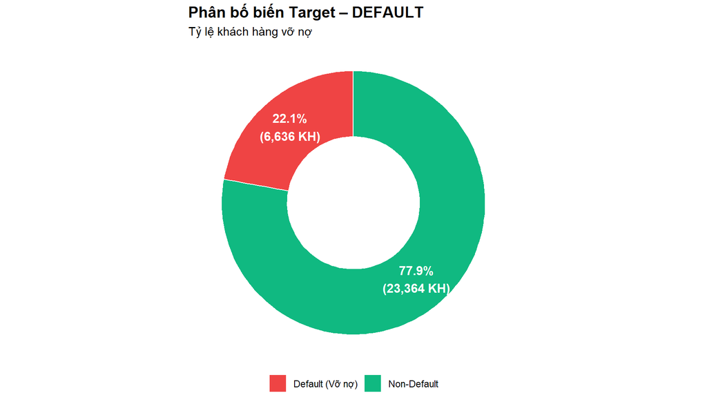

```r
target_summary <- df %>%
  count(DEFAULT) %>%
  mutate(
    label = ifelse(DEFAULT == 1, "Default (Vỡ nợ)", "Non-Default"),
    pct = n / sum(n),
    pct_lab = percent(pct, accuracy = 0.1)
  )

default_pct <- target_summary %>%
  filter(DEFAULT == 1) %>%
  pull(pct_lab)

ggplot(target_summary, aes(x = 2, y = n, fill = label)) +
  geom_col(width = 1, color = "white") +
  coord_polar(theta = "y") +
  xlim(0.5, 2.5) +
  geom_text(aes(label = paste0(pct_lab, "\n(", comma(n), " KH)")),
            position = position_stack(vjust = 0.5),
            size = 4, fontface = "bold", color = "white") +
  annotate("text", x = 0, y = 0,
           label = paste0(default_pct, "\nDefault"),
           size = 6, fontface = "bold") +
  scale_fill_manual(values = c("Default (Vỡ nợ)" = "#ef4444",
                               "Non-Default" = "#10b981")) +
  labs(title = "Phân bố biến Target – DEFAULT",
       subtitle = "Tỷ lệ khách hàng vỡ nợ",
       fill = NULL) +
  theme_void() +
  theme(plot.title = element_text(face = "bold", size = 14),
        plot.subtitle = element_text(size = 11),
        legend.position = "bottom")
```

> ⚠️ **Class Imbalance:** Tỷ lệ 78/22 – cần lưu ý khi đánh giá mô hình, ưu tiên **AUC-ROC & F1** hơn Accuracy đơn thuần.

# 3. Phân phối biến định lượng

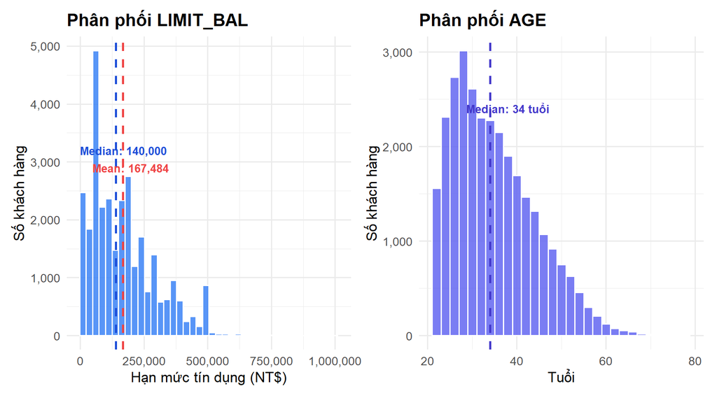

```r
p1 <- ggplot(df, aes(x = LIMIT_BAL)) +
  geom_histogram(bins = 40, fill = "#3b82f6", color = "white", alpha = 0.85) +
  geom_vline(xintercept = median(df$LIMIT_BAL), color = "#1d4ed8",
             linetype = "dashed", linewidth = 1) +
  geom_vline(xintercept = mean(df$LIMIT_BAL), color = "#ef4444",
             linetype = "dashed", linewidth = 1) +
  annotate("text", x = median(df$LIMIT_BAL) + 30000, y = 3200,
           label = paste0("Median: ", comma(median(df$LIMIT_BAL))),
           color = "#1d4ed8", size = 3.5, fontface = "bold") +
  annotate("text", x = mean(df$LIMIT_BAL) + 30000, y = 2900,
           label = paste0("Mean: ", comma(round(mean(df$LIMIT_BAL)))),
           color = "#ef4444", size = 3.5, fontface = "bold") +
  scale_x_continuous(labels = comma) +
  scale_y_continuous(labels = comma) +
  labs(
    title    = "Phân phối LIMIT_BAL",
    x = "Hạn mức tín dụng (NT$)", y = "Số khách hàng"
  ) +
  theme_minimal(base_size = 13) +
  theme(plot.title = element_text(face = "bold"))

p2 <- ggplot(df, aes(x = AGE)) +
  geom_histogram(binwidth = 2, fill = "#6366f1", color = "white", alpha = 0.85) +
  geom_vline(xintercept = median(df$AGE), color = "#4338ca",
             linetype = "dashed", linewidth = 1) +
  annotate("text", x = median(df$AGE) + 4, y = 2400,
           label = paste0("Median: ", median(df$AGE), " tuổi"),
           color = "#4338ca", size = 3.5, fontface = "bold") +
  labs(
    title    = "Phân phối AGE",
    x = "Tuổi", y = "Số khách hàng"
  ) +
  scale_y_continuous(labels = comma) +
  theme_minimal(base_size = 13) +
  theme(plot.title = element_text(face = "bold"))

p1 + p2
```

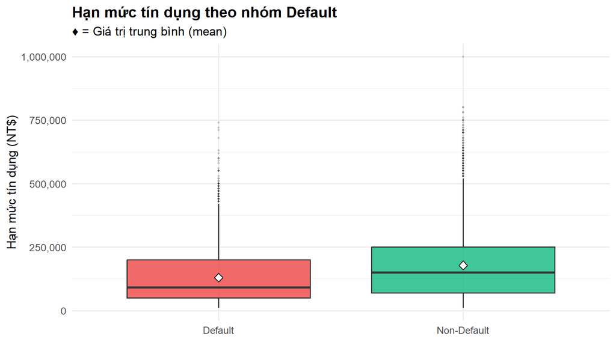

```r
df %>%
  mutate(DEFAULT_label = ifelse(DEFAULT == 1, "Default", "Non-Default")) %>%
  ggplot(aes(x = DEFAULT_label, y = LIMIT_BAL, fill = DEFAULT_label)) +
  geom_boxplot(alpha = 0.8, outlier.alpha = 0.2, outlier.size = 0.8) +
  stat_summary(fun = mean, geom = "point", shape = 23, size = 3,
               fill = "white", color = "black") +
  scale_fill_manual(values = c("Default" = "#ef4444", "Non-Default" = "#10b981")) +
  scale_y_continuous(labels = comma) +
  labs(
    title    = "Hạn mức tín dụng theo nhóm Default",
    subtitle = "♦ = Giá trị trung bình (mean)",
    x = NULL, y = "Hạn mức tín dụng (NT$)",
    fill = NULL
  ) +
  theme_minimal(base_size = 13) +
  theme(plot.title = element_text(face = "bold"),
        legend.position = "none")
```

> **📌** Nhóm Non-Default có median hạn mức cao hơn rõ rệt. LIMIT_BAL là predictor quan trọng.

# 4. Nhân khẩu học & Default Rate

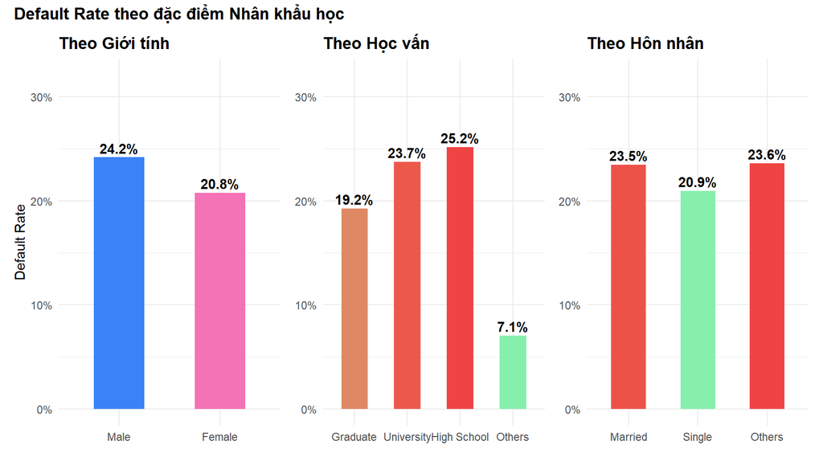

```r
# Hàm tính default rate theo nhóm
# Lưu ý: hàm này dùng trước khi DEFAULT được factor hóa ở Section 8,
# nên DEFAULT vẫn là dạng numeric (0/1) → mean() cho ra tỷ lệ trực tiếp
default_rate <- function(data, group_var) {
  data %>%
    group_by({{ group_var }}) %>%
    summarise(n = n(), rate = mean(as.numeric(as.character(DEFAULT))), .groups = "drop")
}

# dùng trực tiếp các biến đã clean
d_sex <- default_rate(df, SEX)
d_edu <- default_rate(df, EDUCATION)
d_mar <- default_rate(df, MARRIAGE)

# --- Plot ---
p_sex <- ggplot(d_sex, aes(x = SEX, y = rate, fill = SEX)) +
  geom_col(width = 0.5, show.legend = FALSE) +
  geom_text(aes(label = percent(rate, 0.1)), vjust = -0.4, fontface = "bold") +
  scale_fill_manual(values = c("#3b82f6","#f472b6")) +
  scale_y_continuous(labels = percent, limits = c(0, 0.32)) +
  labs(title = "Theo Giới tính", x = NULL, y = "Default Rate") +
  theme_minimal(base_size = 11) +
  theme(plot.title = element_text(face = "bold"))

p_edu <- ggplot(d_edu, aes(x = EDUCATION, y = rate, fill = rate)) +
  geom_col(width = 0.5, show.legend = FALSE) +
  geom_text(aes(label = percent(rate, 0.1)), vjust = -0.4, fontface = "bold") +
  scale_fill_gradient(low = "#86efac", high = "#ef4444") +
  scale_y_continuous(labels = percent, limits = c(0, 0.32)) +
  labs(title = "Theo Học vấn", x = NULL, y = NULL) +
  theme_minimal(base_size = 11) +
  theme(plot.title = element_text(face = "bold"))

p_mar <- ggplot(d_mar, aes(x = MARRIAGE, y = rate, fill = rate)) +
  geom_col(width = 0.5, show.legend = FALSE) +
  geom_text(aes(label = percent(rate, 0.1)), vjust = -0.4, fontface = "bold") +
  scale_fill_gradient(low = "#86efac", high = "#ef4444") +
  scale_y_continuous(labels = percent, limits = c(0, 0.32)) +
  labs(title = "Theo Hôn nhân", x = NULL, y = NULL) +
  theme_minimal(base_size = 11) +
  theme(plot.title = element_text(face = "bold"))

p_sex + p_edu + p_mar +
  plot_annotation(title = "Default Rate theo đặc điểm Nhân khẩu học",
                  theme = theme(plot.title = element_text(face = "bold", size = 13)))
```

> **📌** Tỷ lệ vỡ nợ có sự khác biệt giữa các nhóm nhân khẩu học. Cụ thể, nam có tỷ lệ vỡ nợ cao hơn nữ; nhóm học vấn thấp (High School) có tỷ lệ cao hơn so với các nhóm còn lại; và nhóm “Others” trong tình trạng hôn nhân có tỷ lệ vỡ nợ cao nhất.

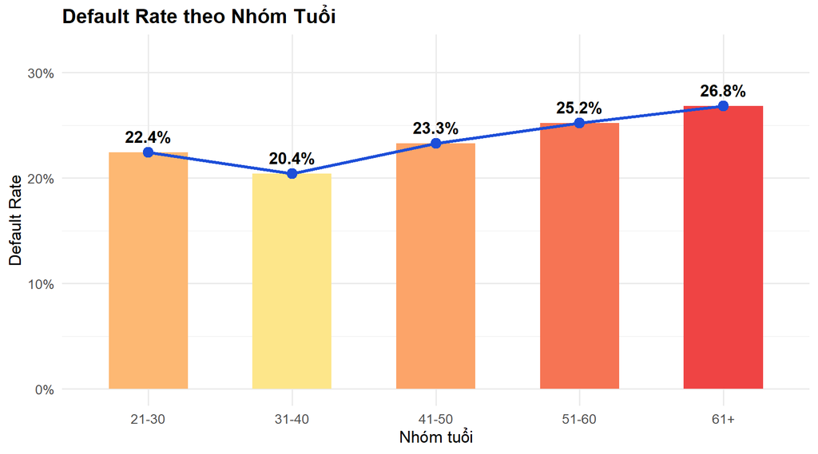

```r
df %>%
  mutate(AGE_GROUP = cut(AGE, breaks = c(20,30,40,50,60,80),
                         labels = c("21-30","31-40","41-50","51-60","61+"))) %>%
  group_by(AGE_GROUP) %>%
  summarise(rate = mean(DEFAULT), n = n(), .groups = "drop") %>%
  ggplot(aes(x = AGE_GROUP, y = rate)) +
  geom_col(aes(fill = rate), width = 0.55, show.legend = FALSE) +
  geom_line(aes(group = 1), color = "#1d4ed8", linewidth = 1.2) +
  geom_point(size = 3.5, color = "#1d4ed8") +
  geom_text(aes(label = percent(rate, 0.1)), vjust = -0.8, fontface = "bold") +
  scale_fill_gradient(low = "#fde68a", high = "#ef4444") +
  scale_y_continuous(labels = percent, limits = c(0, 0.32)) +
  labs(title = "Default Rate theo Nhóm Tuổi",
       x = "Nhóm tuổi", y = "Default Rate") +
  theme_minimal(base_size = 13) +
  theme(plot.title = element_text(face = "bold"))
```

> **📌** Nhóm 31–40 tuổi có tỷ lệ vỡ nợ thấp nhất. Từ sau đó, tỷ lệ vỡ nợ tăng dần theo độ tuổi và cao nhất ở nhóm lớn tuổi.

# 5. Lịch sử Thanh toán (PAY)

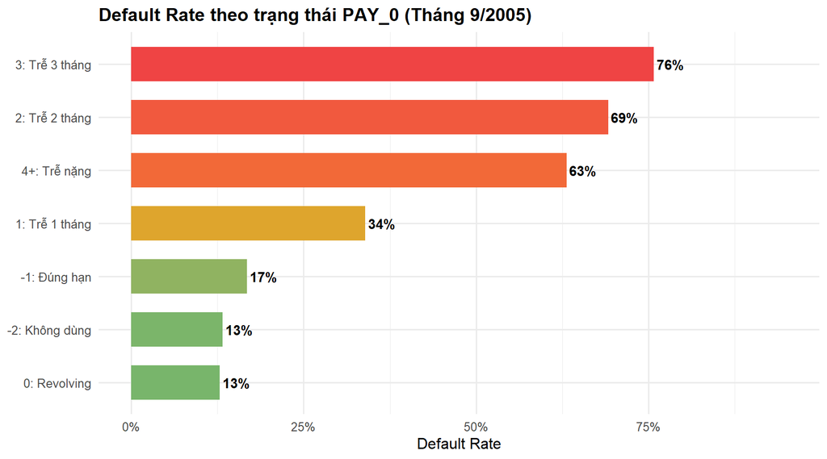

```r
df %>%
  mutate(PAY_0_cat = case_when(
    PAY_0 <= -2 ~ "-2: Không dùng",
    PAY_0 == -1 ~ "-1: Đúng hạn",
    PAY_0 ==  0 ~ " 0: Revolving",
    PAY_0 ==  1 ~ " 1: Trễ 1 tháng",
    PAY_0 ==  2 ~ " 2: Trễ 2 tháng",
    PAY_0 ==  3 ~ " 3: Trễ 3 tháng",
    TRUE         ~ " 4+: Trễ nặng"
  )) %>%
  group_by(PAY_0_cat) %>%
  summarise(rate = mean(DEFAULT), n = n(), .groups = "drop") %>%
  ggplot(aes(x = reorder(PAY_0_cat, rate), y = rate, fill = rate)) +
  geom_col(width = 0.65, show.legend = FALSE) +
  geom_text(aes(label = percent(rate, 1)), hjust = -0.1,
            fontface = "bold", size = 3.8) +
  scale_fill_gradient2(low = "#10b981", mid = "#f59e0b", high = "#ef4444",
                       midpoint = 0.4) +
  scale_y_continuous(labels = percent, limits = c(0, 0.95)) +
  coord_flip() +
  labs(title = "Default Rate theo trạng thái PAY_0 (Tháng 9/2005)",
       x = NULL, y = "Default Rate") +
  theme_minimal(base_size = 12) +
  theme(plot.title = element_text(face = "bold"))
```

> **📌** Tỷ lệ vỡ nợ tăng mạnh theo mức độ trễ thanh toán. Khách hàng trễ từ 2–3 tháng trở lên có xác suất vỡ nợ rất cao, cho thấy lịch sử thanh toán (PAY_0) là một trong những biến dự đoán quan trọng nhất.

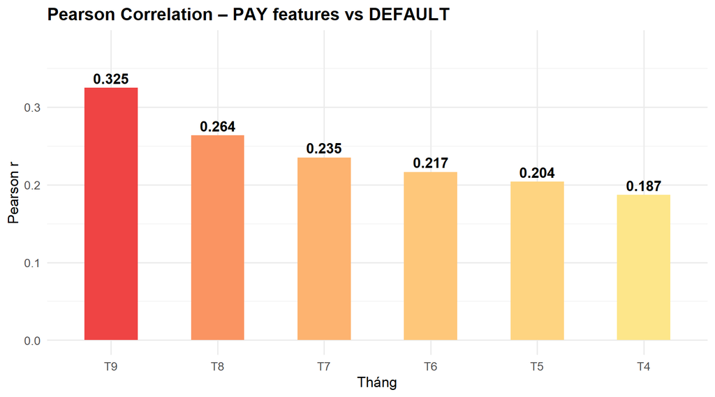

```r
pay_cols <- c("PAY_0","PAY_2","PAY_3","PAY_4","PAY_5","PAY_6")
tibble(
  Feature = pay_cols,
  Thang   = c("T9","T8","T7","T6","T5","T4"),
  Corr    = map_dbl(pay_cols, ~cor(df[[.x]], df$DEFAULT))
) %>%
  ggplot(aes(x = reorder(Thang, -Corr), y = Corr, fill = Corr)) +
  geom_col(width = 0.5, show.legend = FALSE) +
  geom_text(aes(label = round(Corr, 3)), vjust = -0.4, fontface = "bold") +
  scale_fill_gradient(low = "#fde68a", high = "#ef4444") +
  scale_y_continuous(limits = c(0, 0.38)) +
  labs(title = "Pearson Correlation – PAY features vs DEFAULT",
       x = "Tháng", y = "Pearson r") +
  theme_minimal(base_size = 13) +
  theme(plot.title = element_text(face = "bold"))
```

> **📌** Thông tin gần đây quan trọng hơn thông tin xa.

# 6. So sánh BILL_AMT & PAY_AMT theo nhóm Default

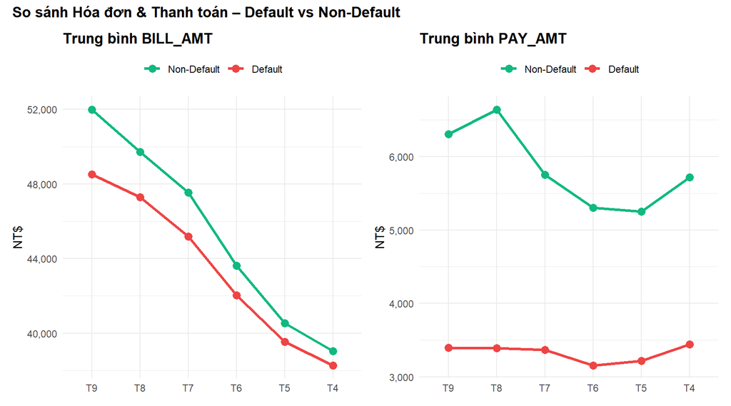

```r
df_fin <- df %>%
  mutate(
    DEFAULT_label = case_when(
      DEFAULT %in% c(0, "0", "No", "Non-Default") ~ "Non-Default",
      DEFAULT %in% c(1, "1", "Yes", "Default") ~ "Default",
      TRUE ~ NA_character_
    ),
    DEFAULT_label = factor(DEFAULT_label, levels = c("Non-Default", "Default"))
  )

months <- c("T9", "T8", "T7", "T6", "T5", "T4")

# BILL_AMT
bill_mean <- df_fin %>%
  dplyr::select(DEFAULT_label, starts_with("BILL_AMT")) %>%
  pivot_longer(-DEFAULT_label, names_to = "var", values_to = "val") %>%
  mutate(
    month_id = as.integer(str_extract(var, "\\d+")),
    Thang = months[month_id]
  ) %>%
  group_by(Thang, DEFAULT_label) %>%
  summarise(mean_val = mean(val, na.rm = TRUE), .groups = "drop") %>%
  mutate(Thang = factor(Thang, levels = months))

p_bill <- ggplot(bill_mean, aes(x = Thang, y = mean_val,
                                color = DEFAULT_label, group = DEFAULT_label)) +
  geom_line(linewidth = 1.2) +
  geom_point(size = 3) +
  scale_color_manual(values = c("Non-Default" = "#10b981",
                                "Default" = "#ef4444")) +
  scale_y_continuous(labels = comma) +
  labs(title = "Trung bình BILL_AMT", x = NULL, y = "NT$", color = NULL) +
  theme_minimal(base_size = 11) +
  theme(plot.title = element_text(face = "bold"),
        legend.position = "top")

# PAY_AMT
pay_mean <- df_fin %>%
  dplyr::select(DEFAULT_label, starts_with("PAY_AMT")) %>%
  pivot_longer(-DEFAULT_label, names_to = "var", values_to = "val") %>%
  mutate(
    month_id = as.integer(str_extract(var, "\\d+")),
    Thang = months[month_id]
  ) %>%
  group_by(Thang, DEFAULT_label) %>%
  summarise(mean_val = mean(val, na.rm = TRUE), .groups = "drop") %>%
  mutate(Thang = factor(Thang, levels = months))

p_pay <- ggplot(pay_mean, aes(x = Thang, y = mean_val,
                              color = DEFAULT_label, group = DEFAULT_label)) +
  geom_line(linewidth = 1.2) +
  geom_point(size = 3) +
  scale_color_manual(values = c("Non-Default" = "#10b981",
                                "Default" = "#ef4444")) +
  scale_y_continuous(labels = comma) +
  labs(title = "Trung bình PAY_AMT", x = NULL, y = "NT$", color = NULL) +
  theme_minimal(base_size = 11) +
  theme(plot.title = element_text(face = "bold"),
        legend.position = "top")

p_bill + p_pay +
  plot_annotation(
    title = "So sánh Hóa đơn & Thanh toán – Default vs Non-Default",
    theme = theme(plot.title = element_text(face = "bold", size = 13))
  )
```

> **📌** Hai nhóm nợ gần giống nhau, nhưng khách hàng không vỡ nợ trả tiền nhiều hơn.

# 7. Ma trận Tương quan

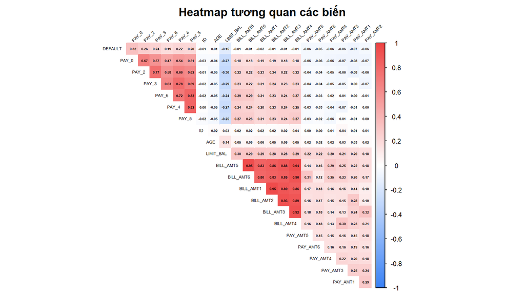

```r
num_vars <- df[sapply(df, is.numeric)]
num_vars <- num_vars[, colSums(!is.na(num_vars)) > 2]

# bỏ biến không thay đổi giá trị
num_vars <- num_vars[, sapply(num_vars, function(x) sd(x, na.rm = TRUE) > 0)]

corr_mat <- cor(num_vars, use = "pairwise.complete.obs")
corr_mat[is.na(corr_mat)] <- 0

corrplot(
  corr_mat,
  method = "color",
  type = "upper",
  order = "hclust",
  addCoef.col = "black",
  number.cex = 0.35,
  tl.col = "black",
  tl.srt = 45,
  tl.cex = 0.45,
  col = colorRampPalette(c("#3b82f6", "white", "#ef4444"))(200),
  diag = FALSE,
  cl.cex = 0.7,
  title = "Heatmap tương quan các biến",
  mar = c(0, 0, 2, 0)
)
```

> **📌 Hiện tượng đa cộng tuyến:** Các biến BILL_AMT có tương quan cao (≈0.8,0.96) – tạo biến AVG_BILL để đại diện và loại các biến BILL_AMT riêng lẻ.

```r
df$AVG_BILL <- rowMeans(df[, c("BILL_AMT1","BILL_AMT2","BILL_AMT3",
                              "BILL_AMT4","BILL_AMT5","BILL_AMT6")])
```

> 👉 Tóm lại, features có khả năng dự báo cao bao gồm nhóm lịch sử thanh toán (PAY), biến tổng hợp dư nợ (AVG_BILL), khả năng chi trả (PAY_AMT), hạn mức tín dụng (LIMIT_BAL) và các đặc điểm nhân khẩu học.

# PHẦN 2 – XÂY DỰNG MÔ HÌNH

# 8. Chuẩn bị dữ liệu cho Modeling

## 8.1 Chọn features & Train/Test Split

```r
# Feature set đã chọn
# - PAY_0–PAY_6: lịch sử thanh toán (predictor quan trọng nhất từ EDA)
# - LIMIT_BAL: hạn mức tín dụng
# - PAY_AMT1–3: 3 tháng gần nhất có tương quan cao hơn với DEFAULT;
#   PAY_AMT4–6 tương quan thấp hơn và có đa cộng tuyến với 3 biến trên → loại
# - AVG_BILL: tổng hợp thay thế BILL_AMT1–6 (đã xử lý multicollinearity ở Section 7)
# - Nhân khẩu học: AGE, EDUCATION, MARRIAGE, SEX
top_features <- c(
  "PAY_0","PAY_2","PAY_3","PAY_4","PAY_5","PAY_6",
  "LIMIT_BAL",
  "PAY_AMT1","PAY_AMT2","PAY_AMT3",
  "AVG_BILL",
  "AGE","EDUCATION","MARRIAGE","SEX"
)

# Chuẩn bị dữ liệu model
df_model <- df %>%
  dplyr::select(all_of(top_features), DEFAULT) %>%
  mutate(
    DEFAULT = factor(DEFAULT, levels = c(0,1), labels = c("No","Yes"))
  )

# Train/Test split 80/20
set.seed(1)
train_idx <- sample(nrow(df_model), floor(0.8 * nrow(df_model)))

train_df <- df_model[train_idx, ]
test_df  <- df_model[-train_idx, ]

cat("Train set:", nrow(train_df), "quan sát\n")
```

```
## Train set: 24000 quan sát
```

```r
cat("Test set:", nrow(test_df), "quan sát\n")
```

```
## Test set: 6000 quan sát
```

## 8.2 Chuẩn hóa (cho KNN)

```r
X_train <- train_df %>%
  dplyr::select(-DEFAULT) %>%
  dplyr::select(where(is.numeric))

X_test <- test_df %>%
  dplyr::select(-DEFAULT) %>%
  dplyr::select(dplyr::all_of(names(X_train)))

X_train_sc <- scale(X_train)

X_test_sc <- scale(
  X_test,
  center = attr(X_train_sc, "scaled:center"),
  scale  = attr(X_train_sc, "scaled:scale")
)

train_labels <- train_df$DEFAULT
test_labels  <- test_df$DEFAULT
```

# 9. Logistic Regression

> Dùng hàm `glm()` với `family = binomial`

## 9.1 Fit mô hình

```r
glm.fit <- glm(DEFAULT ~ .,
               data   = train_df,
               family = binomial)

summary(glm.fit)
```

```
##
## Call:
## glm(formula = DEFAULT ~ ., family = binomial, data = train_df)
##
## Coefficients:
##                        Estimate Std. Error z value Pr(>|z|)
## (Intercept)          -1.027e+00  9.663e-02 -10.626  < 2e-16 ***
## PAY_0                 5.824e-01  1.980e-02  29.412  < 2e-16 ***
## PAY_2                 5.465e-02  2.259e-02   2.419  0.01556 *
## PAY_3                 1.005e-01  2.516e-02   3.994 6.50e-05 ***
## PAY_4                 7.470e-03  2.806e-02   0.266  0.79009
## PAY_5                 5.725e-02  2.981e-02   1.921  0.05476 .
## PAY_6                 8.489e-03  2.441e-02   0.348  0.72799
## LIMIT_BAL            -8.908e-07  1.739e-07  -5.124 2.99e-07 ***
## PAY_AMT1             -1.244e-05  2.469e-06  -5.039 4.69e-07 ***
## PAY_AMT2             -9.180e-06  2.172e-06  -4.226 2.38e-05 ***
## PAY_AMT3             -3.164e-06  1.715e-06  -1.844  0.06517 .
## AVG_BILL             -1.798e-06  3.574e-07  -5.030 4.92e-07 ***
## AGE                   6.688e-03  2.079e-03   3.218  0.00129 **
## EDUCATIONUniversity  -1.165e-01  3.975e-02  -2.930  0.00339 **
## EDUCATIONHigh School -1.468e-01  5.332e-02  -2.754  0.00589 **
## EDUCATIONOthers      -1.255e+00  2.120e-01  -5.921 3.19e-09 ***
## MARRIAGESingle       -1.808e-01  3.876e-02  -4.666 3.08e-06 ***
## MARRIAGEOthers       -2.014e-01  1.483e-01  -1.358  0.17431
## SEXFemale            -1.065e-01  3.440e-02  -3.097  0.00196 **
## ---
## Signif. codes:  0 '***' 0.001 '**' 0.01 '*' 0.05 '.' 0.1 ' ' 1
##
## (Dispersion parameter for binomial family taken to be 1)
##
##     Null deviance: 25271  on 23999  degrees of freedom
## Residual deviance: 22227  on 23981  degrees of freedom
## AIC: 22265
##
## Number of Fisher Scoring iterations: 6
```

## 9.2 Dự đoán xác suất

```r
# type = "response" trả về P(Y=1|X) – xác suất default
glm.probs <- predict(glm.fit, newdata = test_df, type = "response")

# Xem vài giá trị đầu
head(glm.probs, 10)
```

```
##          1          2          3          4          5          6          7
## 0.06285863 0.12853734 0.20584316 0.07119547 0.03633007 0.04386778 0.16253651
##          8          9         10
## 0.22419727 0.24410378 0.12522184
```

## 9.3 Chuyển xác suất → nhãn (ngưỡng 0.5)

```r
# Tạo vector "No" rồi gán "Yes" nếu prob >= 0.5
glm.pred <- rep("No", nrow(test_df))
glm.pred[glm.probs >= 0.5] <- "Yes"
glm.pred <- factor(glm.pred, levels = c("No","Yes"))
```

## 9.4 Confusion Matrix & Metrics

```r
# Confusion Matrix theo ISLR: table()
cm_glm <- table(Predicted = glm.pred, Actual = test_labels)
cm_glm
```

```
##          Actual
## Predicted   No  Yes
##       No  4529 1057
##       Yes  107  307
```

```r
# Test error rate
cat("\nTest Error Rate (LR)  :", round(mean(glm.pred != test_labels), 4), "\n")
```

```
##
## Test Error Rate (LR)  : 0.194
```

```r
cat("Test Accuracy  (LR)  :", round(mean(glm.pred == test_labels),  4), "\n")
```

```
## Test Accuracy  (LR)  : 0.806
```

```r
# Tính chi tiết metrics
tp  <- cm_glm["Yes","Yes"]; tn <- cm_glm["No","No"]
fp  <- cm_glm["Yes","No"];  fn <- cm_glm["No","Yes"]
sens_glm  <- tp / (tp + fn)
spec_glm  <- tn / (tn + fp)
prec_glm  <- tp / (tp + fp)
f1_glm    <- 2 * prec_glm * sens_glm / (prec_glm + sens_glm)
roc_glm   <- roc(test_labels, glm.probs, levels = c("No","Yes"), quiet = TRUE)
auc_glm   <- as.numeric(auc(roc_glm))

cat("Sensitivity (Recall)  :", round(sens_glm, 4), "\n")
```

```
## Sensitivity (Recall)  : 0.2251
```

```r
cat("Specificity           :", round(spec_glm, 4), "\n")
```

```
## Specificity           : 0.9769
```

```r
cat("Precision             :", round(prec_glm, 4), "\n")
```

```
## Precision             : 0.7415
```

```r
cat("F1-Score              :", round(f1_glm,   4), "\n")
```

```
## F1-Score              : 0.3453
```

```r
cat("AUC-ROC               :", round(auc_glm,  4), "\n")
```

```
## AUC-ROC               : 0.7176
```

## 9.5 Odds Ratio

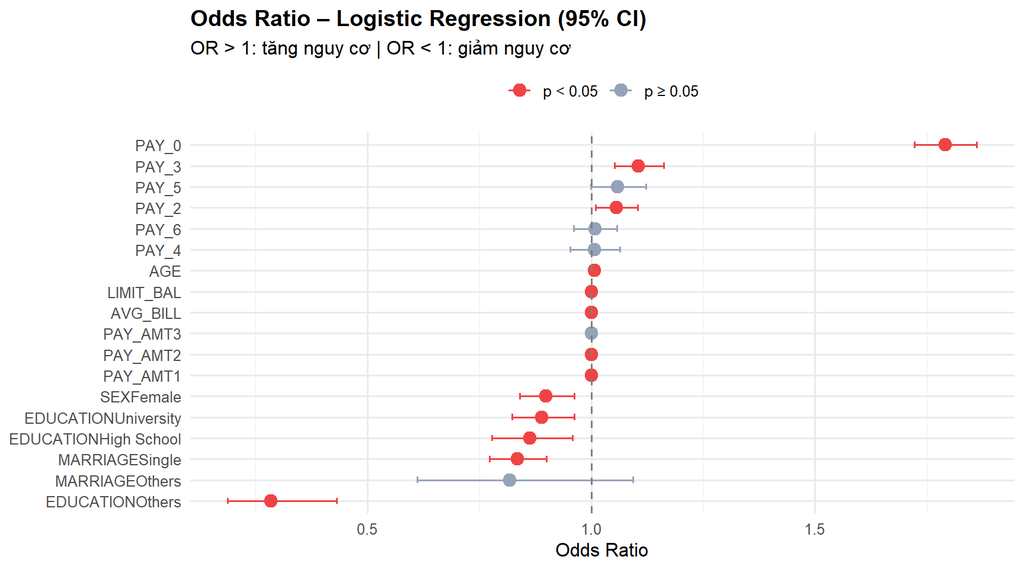

```r
tidy(glm.fit) %>%
  filter(term != "(Intercept)") %>%
  mutate(OR       = exp(estimate),
         lower_ci = exp(estimate - 1.96 * std.error),
         upper_ci = exp(estimate + 1.96 * std.error),
         sig      = ifelse(p.value < 0.05, "p < 0.05", "p ≥ 0.05")) %>%
  arrange(desc(OR)) %>%
  ggplot(aes(x = reorder(term, OR), y = OR, color = sig)) +
  geom_point(size = 3.5) +
  geom_errorbar(aes(ymin = lower_ci, ymax = upper_ci), width = 0.3) +
  geom_hline(yintercept = 1, linetype = "dashed", color = "gray50") +
  scale_color_manual(values = c("p < 0.05" = "#ef4444",
                                "p ≥ 0.05" = "#94a3b8")) +
  coord_flip() +
  labs(title    = "Odds Ratio – Logistic Regression (95% CI)",
       subtitle = "OR > 1: tăng nguy cơ | OR < 1: giảm nguy cơ",
       x = NULL, y = "Odds Ratio", color = NULL) +
  theme_minimal(base_size = 12) +
  theme(plot.title = element_text(face = "bold"), legend.position = "top")
```

> 👉 Ưu điểm của Logistic Regression là kết quả dễ diễn giải thông qua Odds Ratio. Từ biểu đồ, có thể thấy **PAY_0 là yếu tố nổi bật nhất**, khi tình trạng trả nợ gần nhất xấu hơn thì nguy cơ vỡ nợ tăng rõ rệt. Các biến còn lại có tác động nhỏ hơn, trong đó nhiều biến tài chính có OR gần 1 nên không nổi bật bằng nhóm biến lịch sử thanh toán.

# 10. Linear Discriminant Analysis (LDA)

> Dùng hàm `lda()` từ package `MASS`

## 10.1 Fit mô hình

```r
lda.fit <- lda(DEFAULT ~ ., data = train_df)

lda.fit         # in prior, group means, coefficients
```

```
## Call:
## lda(DEFAULT ~ ., data = train_df)
##
## Prior probabilities of groups:
##        No       Yes
## 0.7803333 0.2196667
##
## Group means:
##          PAY_0      PAY_2      PAY_3      PAY_4      PAY_5      PAY_6 LIMIT_BAL
## No  -0.2089919 -0.3011534 -0.3162644 -0.3557240 -0.3884024 -0.4030863  178453.2
## Yes  0.6737481  0.4594082  0.3691199  0.2498103  0.1672989  0.1124810  130014.7
##     PAY_AMT1 PAY_AMT2 PAY_AMT3 AVG_BILL      AGE EDUCATIONUniversity
## No  6344.590 6667.612 5750.258 45650.41 35.40832           0.4578172
## Yes 3385.191 3350.990 3379.274 43202.40 35.73027           0.4977238
##     EDUCATIONHigh School EDUCATIONOthers MARRIAGESingle MARRIAGEOthers
## No             0.1571978     0.019169158      0.5406877     0.01222768
## Yes            0.1856980     0.004931715      0.5053111     0.01327769
##     SEXFemale
## No  0.6161897
## Yes 0.5684750
##
## Coefficients of linear discriminants:
##                                LD1
## PAY_0                 6.977593e-01
## PAY_2                 1.124851e-01
## PAY_3                 1.175260e-01
## PAY_4                 2.388386e-03
## PAY_5                 6.303426e-02
## PAY_6                 1.057016e-02
## LIMIT_BAL            -7.693711e-07
## PAY_AMT1             -4.341947e-06
## PAY_AMT2             -9.906033e-07
## PAY_AMT3             -4.116925e-07
## AVG_BILL             -3.761675e-06
## AGE                   9.236626e-03
## EDUCATIONUniversity  -1.318123e-01
## EDUCATIONHigh School -1.568185e-01
## EDUCATIONOthers      -9.186635e-01
## MARRIAGESingle       -2.019863e-01
## MARRIAGEOthers       -2.355289e-01
## SEXFemale            -1.026473e-01
```

> **📌** - **Prior probabilities**: P(Y=0) và P(Y=1) ước lượng từ train set. - **Group means**: trung bình mỗi feature theo từng lớp – feature nào chênh lệch lớn thì phân biệt tốt. - **Coefficients of linear discriminants**: hệ số tạo nên hàm phân biệt LD1. Dấu và độ lớn cho biết chiều và mức độ đóng góp.

## 10.2 Vẽ Discriminant Plot

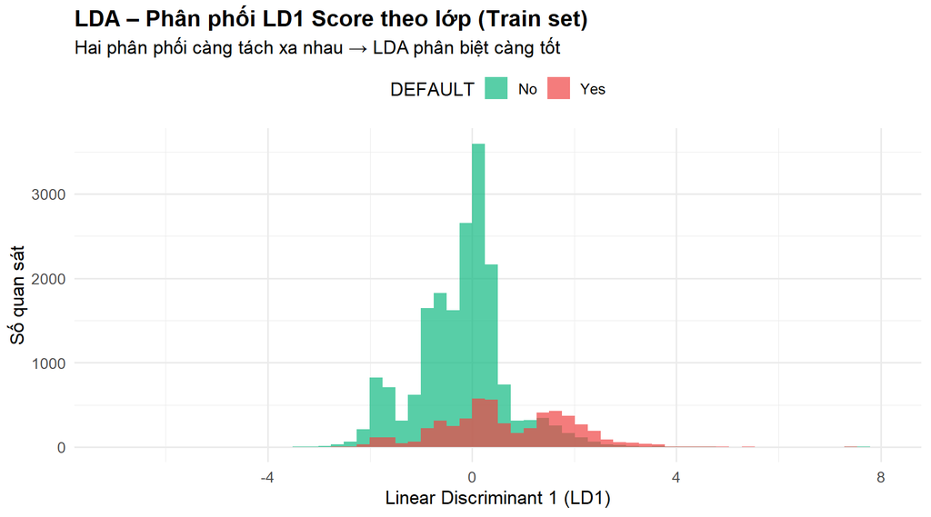

```r
lda.pred.train <- predict(lda.fit, train_df)

# LD1 scores theo từng lớp
lda_df <- tibble(
  LD1     = lda.pred.train$x[, 1],
  DEFAULT = train_df$DEFAULT
)

ggplot(lda_df, aes(x = LD1, fill = DEFAULT)) +
  geom_histogram(bins = 60, alpha = 0.7, position = "identity") +
  scale_fill_manual(values = c("No" = "#10b981", "Yes" = "#ef4444")) +
  labs(title    = "LDA – Phân phối LD1 Score theo lớp (Train set)",
       subtitle = "Hai phân phối càng tách xa nhau → LDA phân biệt càng tốt",
       x = "Linear Discriminant 1 (LD1)", y = "Số quan sát", fill = "DEFAULT") +
  theme_minimal(base_size = 13) +
  theme(plot.title = element_text(face = "bold"), legend.position = "top")
```

> 👉 Phân phối LD1 cho thấy nhóm vỡ nợ có xu hướng nằm lệch sang phải so với nhóm không vỡ nợ, chứng tỏ LDA có khả năng phân biệt hai lớp ở mức nhất định. Tuy nhiên, hai nhóm vẫn chồng lấn đáng kể quanh vùng trung tâm, nên khả năng tách lớp chưa thật sự rõ ràng.

## 10.3 Dự đoán & Đánh giá

```r
# predict.lda() trả về list gồm $class, $posterior, $x
lda.pred <- predict(lda.fit, newdata = test_df)

# Nhãn dự đoán
lda.class <- lda.pred$class

# Confusion Matrix
cm_lda <- table(Predicted = lda.class, Actual = test_labels)
cm_lda
```

```
##          Actual
## Predicted   No  Yes
##       No  4515 1037
##       Yes  121  327
```

```r
cat("\nTest Error Rate (LDA):", round(mean(lda.class != test_labels), 4), "\n")
```

```
##
## Test Error Rate (LDA): 0.193
```

```r
cat("Test Accuracy   (LDA):", round(mean(lda.class == test_labels),  4), "\n")
```

```
## Test Accuracy   (LDA): 0.807
```

```r
tp  <- cm_lda["Yes","Yes"]; tn <- cm_lda["No","No"]
fp  <- cm_lda["Yes","No"];  fn <- cm_lda["No","Yes"]
sens_lda  <- tp / (tp + fn)
spec_lda  <- tn / (tn + fp)
prec_lda  <- tp / (tp + fp)
f1_lda    <- 2 * prec_lda * sens_lda / (prec_lda + sens_lda)
roc_lda   <- roc(test_labels, lda.pred$posterior[,"Yes"],
                 levels = c("No","Yes"), quiet = TRUE)
auc_lda   <- as.numeric(auc(roc_lda))

cat("Sensitivity :", round(sens_lda, 4), "\n")
```

```
## Sensitivity : 0.2397
```

```r
cat("Specificity :", round(spec_lda, 4), "\n")
```

```
## Specificity : 0.9739
```

```r
cat("Precision   :", round(prec_lda, 4), "\n")
```

```
## Precision   : 0.7299
```

```r
cat("F1-Score    :", round(f1_lda,   4), "\n")
```

```
## F1-Score    : 0.3609
```

```r
cat("AUC-ROC     :", round(auc_lda,  4), "\n")
```

```
## AUC-ROC     : 0.7132
```

# 11. Quadratic Discriminant Analysis (QDA)

> Dùng hàm `qda()` từ package `MASS`

## 11.1 Fit mô hình

```r
qda.fit <- qda(DEFAULT ~ ., data = train_df)

qda.fit
```

```
## Call:
## qda(DEFAULT ~ ., data = train_df)
##
## Prior probabilities of groups:
##        No       Yes
## 0.7803333 0.2196667
##
## Group means:
##          PAY_0      PAY_2      PAY_3      PAY_4      PAY_5      PAY_6 LIMIT_BAL
## No  -0.2089919 -0.3011534 -0.3162644 -0.3557240 -0.3884024 -0.4030863  178453.2
## Yes  0.6737481  0.4594082  0.3691199  0.2498103  0.1672989  0.1124810  130014.7
##     PAY_AMT1 PAY_AMT2 PAY_AMT3 AVG_BILL      AGE EDUCATIONUniversity
## No  6344.590 6667.612 5750.258 45650.41 35.40832           0.4578172
## Yes 3385.191 3350.990 3379.274 43202.40 35.73027           0.4977238
##     EDUCATIONHigh School EDUCATIONOthers MARRIAGESingle MARRIAGEOthers
## No             0.1571978     0.019169158      0.5406877     0.01222768
## Yes            0.1856980     0.004931715      0.5053111     0.01327769
##     SEXFemale
## No  0.6161897
## Yes 0.5684750
```

> **📌 LDA vs QDA :** - LDA giả định $\Sigma_k = \Sigma$ (ma trận hiệp phương sai bằng nhau giữa các lớp) → ranh giới **tuyến tính**. - QDA cho phép $\Sigma_k$ khác nhau → ranh giới **bậc hai (quadratic)**. - QDA linh hoạt hơn nhưng cần ước lượng nhiều tham số hơn → cần nhiều dữ liệu.

## 11.2 Dự đoán & Đánh giá

```r
qda.pred <- predict(qda.fit, newdata = test_df)

qda.class <- qda.pred$class

cm_qda <- table(Predicted = qda.class, Actual = test_labels)
cm_qda
```

```
##          Actual
## Predicted   No  Yes
##       No  3233  468
##       Yes 1403  896
```

```r
cat("\nTest Error Rate (QDA):", round(mean(qda.class != test_labels), 4), "\n")
```

```
##
## Test Error Rate (QDA): 0.3118
```

```r
cat("Test Accuracy   (QDA):", round(mean(qda.class == test_labels),  4), "\n")
```

```
## Test Accuracy   (QDA): 0.6882
```

```r
tp  <- cm_qda["Yes","Yes"]; tn <- cm_qda["No","No"]
fp  <- cm_qda["Yes","No"];  fn <- cm_qda["No","Yes"]
sens_qda  <- tp / (tp + fn)
spec_qda  <- tn / (tn + fp)
prec_qda  <- tp / (tp + fp)
f1_qda    <- 2 * prec_qda * sens_qda / (prec_qda + sens_qda)
roc_qda   <- roc(test_labels, qda.pred$posterior[,"Yes"],
                 levels = c("No","Yes"), quiet = TRUE)
auc_qda   <- as.numeric(auc(roc_qda))

cat("Sensitivity :", round(sens_qda, 4), "\n")
```

```
## Sensitivity : 0.6569
```

```r
cat("Specificity :", round(spec_qda, 4), "\n")
```

```
## Specificity : 0.6974
```

```r
cat("Precision   :", round(prec_qda, 4), "\n")
```

```
## Precision   : 0.3897
```

```r
cat("F1-Score    :", round(f1_qda,   4), "\n")
```

```
## F1-Score    : 0.4892
```

```r
cat("AUC-ROC     :", round(auc_qda,  4), "\n")
```

```
## AUC-ROC     : 0.7179
```

# 12. K-Nearest Neighbors (KNN)

> Dùng hàm `knn()` từ package `class`  
> **Lưu ý bắt buộc:** `knn()` yêu cầu dữ liệu đã được **chuẩn hóa**

## 12.1 Tìm K tối ưu

```r
set.seed(1)

k_values <- c(1, 3, 5, 7, 9, 11, 15, 21, 31, 41, 51, 71, 101)
error_k  <- numeric(length(k_values))

for (i in seq_along(k_values)) {
  knn.pred     <- knn(train = X_train_sc,
                      test  = X_test_sc,
                      cl    = train_labels,
                      k     = k_values[i])
  error_k[i]   <- mean(knn.pred != test_labels)
}

k_df <- tibble(K = k_values, ErrorRate = error_k)
print(k_df)
```

```
## # A tibble: 13 × 2
##        K ErrorRate
##    <dbl>     <dbl>
##  1     1     0.270
##  2     3     0.228
##  3     5     0.207
##  4     7     0.202
##  5     9     0.197
##  6    11     0.192
##  7    15     0.187
##  8    21     0.187
##  9    31     0.187
## 10    41     0.186
## 11    51     0.186
## 12    71     0.188
## 13   101     0.189
```

```r
best_k <- k_values[which.min(error_k)]
cat("\nK tối ưu:", best_k, "| Error Rate:", round(min(error_k), 4), "\n")
```

```
##
## K tối ưu: 41 | Error Rate: 0.1862
```

> 👉 Với mô hình KNN, ta thử nhiều giá trị khác nhau của K và so sánh sai số phân loại tương ứng. Sau đó, ta chọn giá trị K cho sai số nhỏ nhất để xây dựng mô hình cuối cùng. Việc thử nhiều giá trị K là cần thiết vì nếu K quá nhỏ thì mô hình dễ bị nhiễu, còn nếu K quá lớn thì mô hình có thể phân loại kém linh hoạt.

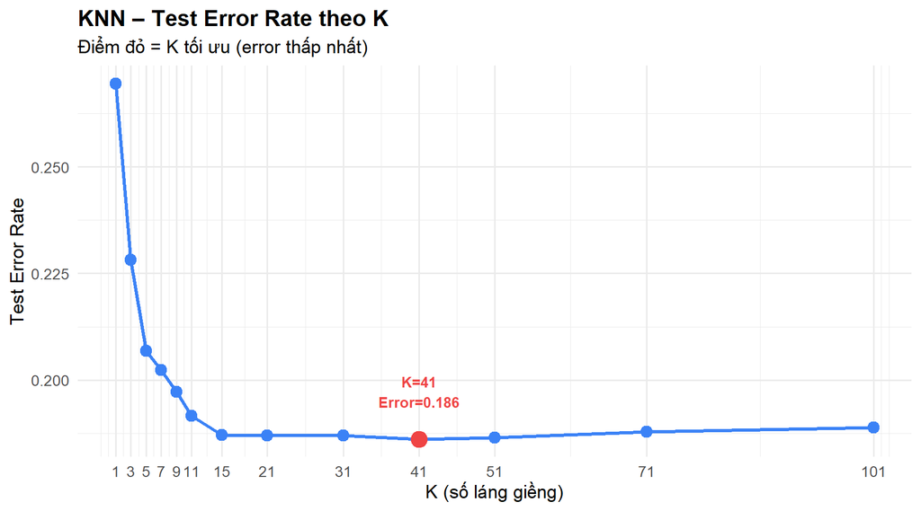

```r
ggplot(k_df, aes(x = K, y = ErrorRate)) +
  geom_line(color = "#3b82f6", linewidth = 1.2) +
  geom_point(size = 3.5, color = "#3b82f6") +
  geom_point(data = k_df %>% filter(K == best_k),
             color = "#ef4444", size = 5) +
  geom_text(data = k_df %>% filter(K == best_k),
            aes(label = paste0("K=", K, "\nError=", round(ErrorRate, 3))),
            vjust = -1, color = "#ef4444", fontface = "bold", size = 3.5) +
  scale_x_continuous(breaks = k_values) +
  labs(title    = "KNN – Test Error Rate theo K",
       subtitle = "Điểm đỏ = K tối ưu (error thấp nhất)",
       x = "K (số láng giềng)", y = "Test Error Rate") +
  theme_minimal(base_size = 13) +
  theme(plot.title = element_text(face = "bold"))
```

## 12.2 Fit với K tối ưu & Đánh giá

```r
set.seed(1)

knn.pred <- knn(train = X_train_sc,
                test  = X_test_sc,
                cl    = train_labels,
                k     = best_k,
                prob  = TRUE)

cm_knn <- table(Predicted = knn.pred, Actual = test_labels)
cm_knn
```

```
##          Actual
## Predicted   No  Yes
##       No  4414  896
##       Yes  222  468
```

```r
cat("\nTest Error Rate (KNN, K =", best_k, "):",
    round(mean(knn.pred != test_labels), 4), "\n")
```

```
##
## Test Error Rate (KNN, K = 41 ): 0.1863
```

```r
cat("Test Accuracy   (KNN, K =", best_k, "):",
    round(mean(knn.pred == test_labels),  4), "\n")
```

```
## Test Accuracy   (KNN, K = 41 ): 0.8137
```

```r
tp  <- cm_knn["Yes","Yes"]; tn <- cm_knn["No","No"]
fp  <- cm_knn["Yes","No"];  fn <- cm_knn["No","Yes"]
sens_knn <- tp / (tp + fn)
spec_knn <- tn / (tn + fp)
prec_knn <- tp / (tp + fp)
f1_knn   <- 2 * prec_knn * sens_knn / (prec_knn + sens_knn)

# Lấy xác suất lớp "Yes" cho ROC
prob_knn_raw <- attr(knn.pred, "prob")
prob_knn     <- ifelse(knn.pred == "Yes", prob_knn_raw, 1 - prob_knn_raw)
roc_knn      <- roc(test_labels, prob_knn, levels = c("No","Yes"), quiet = TRUE)
auc_knn      <- as.numeric(auc(roc_knn))

cat("Sensitivity :", round(sens_knn, 4), "\n")
```

```
## Sensitivity : 0.3431
```

```r
cat("Specificity :", round(spec_knn, 4), "\n")
```

```
## Specificity : 0.9521
```

```r
cat("Precision   :", round(prec_knn, 4), "\n")
```

```
## Precision   : 0.6783
```

```r
cat("F1-Score    :", round(f1_knn,   4), "\n")
```

```
## F1-Score    : 0.4557
```

```r
cat("AUC-ROC     :", round(auc_knn,  4), "\n")
```

```
## AUC-ROC     : 0.7546
```

> 👉 KNN với **K = 41** cho kết quả khá tốt và đặc biệt mạnh trong việc nhận diện nhóm không vỡ nợ với **specificity = 95.21%**, đồng thời có **sensitivity = 34.31%**, cải thiện so với LDA. So với QDA, KNN cho kết quả ổn định hơn và cân bằng hơn giữa độ chính xác tổng thể và khả năng phân biệt hai lớp. Tuy nhiên, cần lưu ý rằng K được chọn trực tiếp trên test set – để khách quan hơn, thực tế nên dùng **k-fold cross-validation** trên train set để tránh leakage.

# 13. So sánh tổng hợp các mô hình

## 13.1 Bảng Metrics

```r
results <- tibble(
  Model       = c("Logistic Regression", "LDA", "QDA",
                  paste0("KNN (K=", best_k, ")")),
  Accuracy    = round(c(mean(glm.pred  == test_labels),
                        mean(lda.class == test_labels),
                        mean(qda.class == test_labels),
                        mean(knn.pred  == test_labels)), 4),
  Sensitivity = round(c(sens_glm, sens_lda, sens_qda, sens_knn), 4),
  Specificity = round(c(spec_glm, spec_lda, spec_qda, spec_knn), 4),
  Precision   = round(c(prec_glm, prec_lda, prec_qda, prec_knn), 4),
  F1_Score    = round(c(f1_glm,   f1_lda,   f1_qda,   f1_knn),   4),
  AUC_ROC     = round(c(auc_glm,  auc_lda,  auc_qda,  auc_knn),  4)
)

results
```

| Model | Accuracy | Sensitivity | Specificity | Precision | F1_Score | AUC_ROC |
| --- | --- | --- | --- | --- | --- | --- |
| Logistic Regression | 0.8060 | 0.2251 | 0.9769 | 0.7415 | 0.3453 | 0.7176 |
| LDA | 0.8070 | 0.2397 | 0.9739 | 0.7299 | 0.3609 | 0.7132 |
| QDA | 0.6882 | 0.6569 | 0.6974 | 0.3897 | 0.4892 | 0.7179 |
| KNN (K=41) | 0.8137 | 0.3431 | 0.9521 | 0.6783 | 0.4557 | 0.7546 |

## 13.2 ROC Curve – 4 mô hình

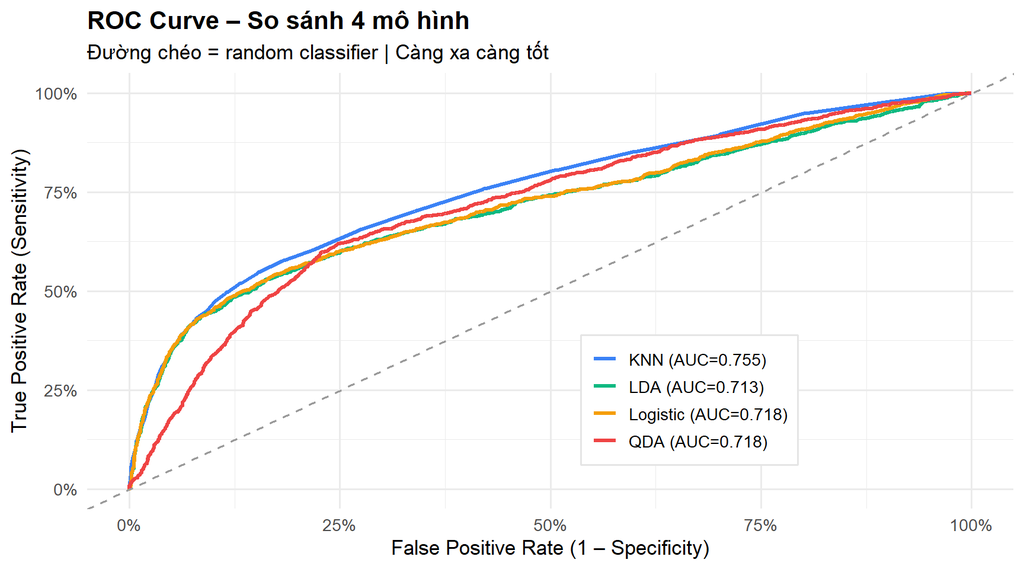

```r
roc_df <- bind_rows(
  tibble(Model = paste0("Logistic (AUC=",round(auc_glm,3),")"),
         FPR = 1-roc_glm$specificities, TPR = roc_glm$sensitivities),
  tibble(Model = paste0("LDA (AUC=",     round(auc_lda,3),")"),
         FPR = 1-roc_lda$specificities,  TPR = roc_lda$sensitivities),
  tibble(Model = paste0("QDA (AUC=",     round(auc_qda,3),")"),
         FPR = 1-roc_qda$specificities,  TPR = roc_qda$sensitivities),
  tibble(Model = paste0("KNN (AUC=",     round(auc_knn,3),")"),
         FPR = 1-roc_knn$specificities,  TPR = roc_knn$sensitivities)
)

ggplot(roc_df, aes(x = FPR, y = TPR, color = Model)) +
  geom_line(linewidth = 1.1) +
  geom_abline(linetype = "dashed", color = "gray60") +
  scale_color_manual(values = c("#3b82f6","#10b981","#f59e0b","#ef4444")) +
  scale_x_continuous(labels = percent) +
  scale_y_continuous(labels = percent) +
  labs(title    = "ROC Curve – So sánh 4 mô hình",
       subtitle = "Đường chéo = random classifier | Càng xa càng tốt",
       x = "False Positive Rate (1 – Specificity)",
       y = "True Positive Rate (Sensitivity)",
       color = NULL) +
  theme_minimal(base_size = 13) +
  theme(plot.title      = element_text(face = "bold"),
        legend.position = c(0.65, 0.25),
        legend.background = element_rect(fill = "white", color = "gray90"))
```

> 👉 Đường ROC cho thấy cả 4 mô hình đều tốt hơn dự đoán ngẫu nhiên. Trong đó, KNN có AUC cao nhất (0,755) nên mô hình này có khả năng phân biệt hai lớp tốt nhất.

## 13.3 Biểu đồ so sánh metrics

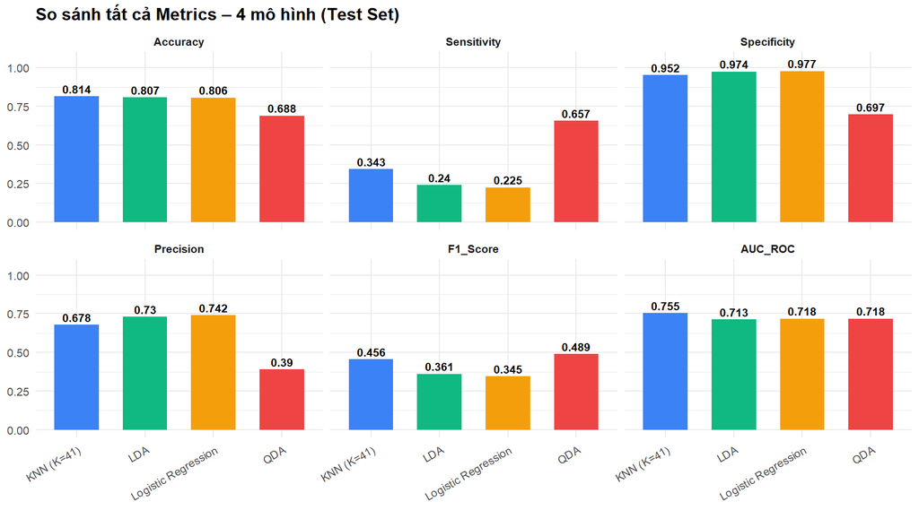

```r
results %>%
  pivot_longer(-Model, names_to = "Metric", values_to = "Value") %>%
  mutate(Metric = factor(Metric,
    levels = c("Accuracy","Sensitivity","Specificity","Precision","F1_Score","AUC_ROC"))) %>%
  ggplot(aes(x = Model, y = Value, fill = Model)) +
  geom_col(width = 0.65, show.legend = FALSE) +
  geom_text(aes(label = round(Value, 3)), vjust = -0.4, size = 2.8, fontface = "bold") +
  facet_wrap(~Metric, ncol = 3) +
  scale_fill_manual(values = c("#3b82f6","#10b981","#f59e0b","#ef4444")) +
  scale_y_continuous(limits = c(0, 1.05)) +
  labs(title = "So sánh tất cả Metrics – 4 mô hình (Test Set)",
       x = NULL, y = NULL) +
  theme_minimal(base_size = 10) +
  theme(plot.title  = element_text(face = "bold"),
        axis.text.x = element_text(angle = 30, hjust = 1),
        strip.text  = element_text(face = "bold"))
```

# 14. Kết luận

```r
best_auc <- results %>% slice_max(AUC_ROC, n = 1)
best_f1  <- results %>% slice_max(F1_Score, n = 1)

cat("🏆 Best AUC-ROC :", best_auc$Model, "–", best_auc$AUC_ROC, "\n")
```

```
## 🏆 Best AUC-ROC : KNN (K=41) – 0.7546
```

```r
cat("🎯 Best F1-Score:", best_f1$Model,  "–", best_f1$F1_Score,  "\n")
```

```
## 🎯 Best F1-Score: QDA – 0.4892
```

## 📋 Tổng kết

> | Mô hình | Hàm R | Đặc điểm |
> | --- | --- | --- |
> | **Logistic Regression** | `glm(..., family=binomial)` | Dễ giải thích qua Odds Ratio; kết quả ổn định, specificity cao |
> | **LDA** | `MASS::lda()` | Ranh giới tuyến tính; accuracy tốt, nhận diện tốt nhóm không vỡ nợ |
> | **QDA** | `MASS::qda()` | Linh hoạt hơn LDA; sensitivity và F1-score cao nhất |
> | **KNN** | `class::knn()` | Không tham số, cần chuẩn hóa dữ liệu; AUC-ROC cao nhất, khả năng phân biệt hai lớp tốt theo tiêu chí AUC. |

> **💡** Nhìn chung, việc lựa chọn mô hình không nên chỉ dựa hoàn toàn vào các chỉ số đánh giá. Với bài toán tín dụng, Logistic Regression vẫn là một lựa chọn rất phù hợp vì kết quả của mô hình khá ổn định, đồng thời dễ giải thích thông qua Odds Ratio. Điều này giúp người ra quyết định hiểu được yếu tố nào làm tăng hoặc giảm rủi ro vỡ nợ của khách hàng.

> Do đó, trong bài toán dự đoán vỡ nợ thẻ tín dụng, Logistic Regression được lựa chọn là mô hình phù hợp nhất.